# Donkeys Code

Eric Tay, Daniel Zhou, Sherry Hu, Jason McEachin

5/26/2020

```r
# One will need to download these packages
library(dplyr) # dplyr==0.8.5
```

```r
library(ggplot2) # ggplot2==3.2.1
library(olsrr) # olsrr==0.5.3
library(lmtest) # lmtest==0.9-37
library(numbers) # numbers==0.7-5
library(cowplot) # cowplot==1.0.0
library(rms) # rms==5.1-4
library(plyr) # plyr==1.8.5
load(file = "donkeys.Rda")
```

```r
# Read in donkeys
donkeys <- data.frame(donkeys)

# Remove outliers and sort based on weight as per Milner and Rouge

# drop BCS = 4.5 and BCS = 1
donkeys <- subset(donkeys, BCS!=4.5 & BCS!=1)

# drop baby donkey
baby <- subset(donkeys, Weight == 27)
donkeys <- subset(donkeys, Weight != 27)

# Order donkeys by weight
donkeys <- donkeys[order(donkeys$Weight),]
```

```r
# We bin all ages > 5, this is easier for the vet to determine, since ages are determined by teeth, or by owner's knowledge
# Doing so also leads to slightly better performance, possibly because Age binning above 5 years was not accurate
levels(donkeys$Age) <- c(levels(donkeys$Age), ">5")
donkeys$Age[donkeys$Age == "5-10"] <- ">5"
donkeys$Age[donkeys$Age == "10-15"] <- ">5"
donkeys$Age[donkeys$Age == "15-20"] <- ">5"
donkeys$Age[donkeys$Age == ">20"] <- ">5"

# We bin BCS = 1.5 and BCS = 2, reasons for doing so will be explained later
donkeys_binned <- donkeys
donkeys_binned$BCS[donkeys_binned$BCS == "1.5"] <- "2"
donkeys_binned$BCS <- revalue(donkeys_binned$BCS, c("2"="1.5/2"))

# train-test split, take every 5th donkey for test set, as per Milner and Rouge
# train/test does not have BCS = 1.5/2 binned together, while train_binned/test_binned does
train <- NULL
test <- NULL
train_binned <- NULL
test_binned <- NULL

for(i in 1:nrow(donkeys)){
  if (mod(i,5) == 0){
    test <- rbind(test, donkeys[i,])
    test_binned <- rbind(test_binned, donkeys_binned[i,])
  }
  else{
    train <- rbind(train, donkeys[i,])
    train_binned <- rbind(train_binned, donkeys_binned[i,])
  }
}

# Milner and Rouge trained their data only on donkeys with BCS 3, and Age > 5.

train_reproducing <- subset(train, BCS==3.0)
train_reproducing <- subset(train_reproducing, Age!='<2')
train_reproducing <- subset(train_reproducing, Age!='2-5')
```

# Reproducing their code

```r
# ordinary least squares
model.rep = lm(2*(sqrt(Weight)-1) ~ log(Length) + log(Girth), data=train_reproducing)
summary(model.rep)
```

```
##
## Call:
## lm(formula = 2 * (sqrt(Weight) - 1) ~ log(Length) + log(Girth),
##     data = train_reproducing)
##
## Residuals:
##      Min       1Q   Median       3Q      Max
## -1.76762 -0.43941  0.02973  0.47535  1.63378
##
## Coefficients:
##             Estimate Std. Error t value Pr(>|t|)
## (Intercept) -103.394      7.959 -12.990  < 2e-16 ***
## log(Length)    8.057      0.982   8.205 4.81e-14 ***
## log(Girth)    18.837      1.610  11.702  < 2e-16 ***
## ---
## Signif. codes:  0 '***' 0.001 '**' 0.01 '*' 0.05 '.' 0.1 ' ' 1
##
## Residual standard error: 0.6924 on 175 degrees of freedom
## Multiple R-squared:  0.6003, Adjusted R-squared:  0.5957
## F-statistic: 131.4 on 2 and 175 DF,  p-value: < 2.2e-16
```

- Values are different because of the asymmetric loss function they implemented.
- b0_given = -107
- b1_given = 19.91
- b2_given = 7.712
- We will use their given values to reproduce their results, and compare with our proposed model later.

```r
f = -107 + 19.91*log(test$Girth)
g = 7.712*log(test$Length)
raw_weight = (((f+g)/2) + 1)^2 #This is predicted weight without additive adjustments
```

```r
levels(test$Age)
```

```
## [1] "<2"    "2-5"   "5-10"  "10-15" "15-20" ">20"   ">5"
```

```r
levels(test$BCS)
```

```
## [1] "1"   "1.5" "2"   "2.5" "3"   "3.5" "4"   "4.5"
```

```r
#This implements the additive adjustments
age_adjustment <- function(num){
  list = c(-8,-4,0,0,0,0,0)
  return(list[num])
}
bcs_adjustment <- function(num){
  list = c(NA,-10,-6,-5,0,6,14,NA)
  return(list[num])
}
age = sapply(as.numeric(test$Age),age_adjustment)
bcs = sapply(as.numeric(test$BCS),bcs_adjustment)

author_predicted = raw_weight + age + bcs #This is predicted weight with additive adjustments
```

```r
#Plot a histogram of relative errors
plot_hist <- function(predicted, actual){
  actual_over_predicted = actual/predicted
  n = length(actual_over_predicted)
  h <- hist(actual_over_predicted, breaks = 4, main = "Distribution of Relative Errors, actual/predicted", ylim=c(0,60), xlab = "Relative error, actual/predicted")
  text(h$mids,h$counts,labels=paste(signif(100*h$counts/n,3),"%"), adj=c(0.5, -0.5))
}
```

```r
#Plot a histogram of residuals
plot_hist_residuals <- function(predicted, actual, breaks){
  residual = actual - predicted
  h <- hist(residual, breaks = breaks, main = "Distribution of Residuals, actual - predicted", ylim=c(0,25), xlab = "Residual, Actual Weight - Predicted Weight")
  text(h$mids,h$counts,labels=h$counts, adj=c(0.5, -0.5))
}
```

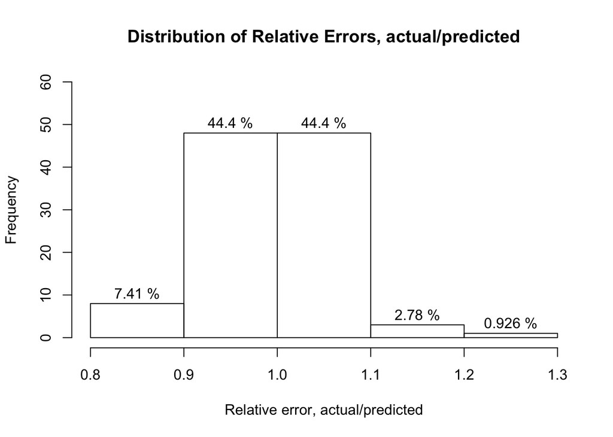

```r
# We reproduce their histogram
plot_hist(author_predicted, test$Weight)
```

```r
# We plot the actual versus predicted weights
plot_predictions <- function(predicted){
  ggplot(test, aes(x = predicted, y = Weight)) + geom_point(color = "red") + xlim(75,225) + ylim(75,225) + geom_abline(intercept = 0, slope = 1, size=0.9) +
  geom_abline(intercept = 0, slope = 1.1, color="gray", linetype = "dashed", size=1) +
  geom_abline(intercept = 0, slope = .9, color="gray", linetype = "dashed", size=1) +
  geom_abline(intercept = 0, slope = .8, color="gray", linetype = "dotted", size=1) +
  geom_abline(intercept = 0, slope = 1.2, color="gray", linetype = "dotted", size=1) +
  scale_x_continuous(name = "Predicted", breaks = seq(75,225,25), limits = c(75,225)) +
  scale_y_continuous(name = "Actual Weights", breaks = seq(75,225,25), limits = c(75,225))
}
```

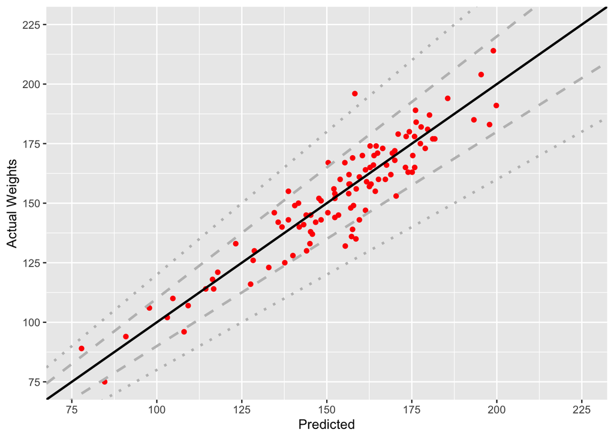

```r
# We reproduce their graph
options(warn=-1)
plot_predictions(author_predicted)
```

- Reproduction of histogram and graph give us confidence that we have selected the correct training and testing samples, and our predictions using their model are accurate.

# EDA

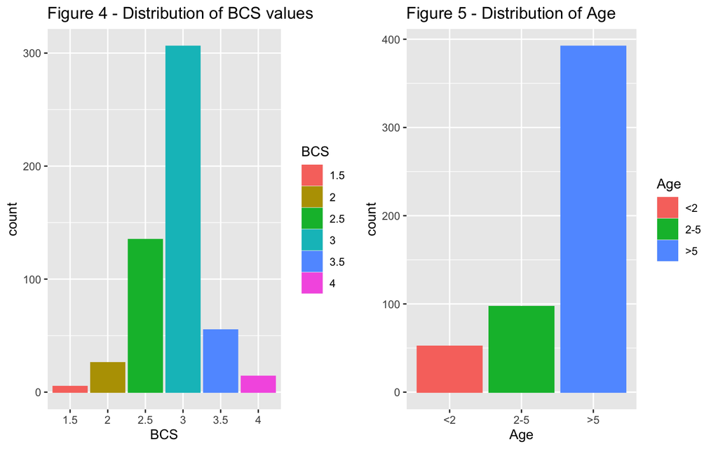

```r
# Code and idea obtained from Wang, Xu, Zhang

p5 <- ggplot(data = donkeys) +
  geom_bar(mapping = aes(x = BCS, color = BCS, fill = BCS)) + labs(title = "Figure 4 - Distribution of BCS values")

p6 <- ggplot(data = donkeys) +
  geom_bar(mapping = aes(x = Age, color = Age, fill = Age)) + labs(title = "Figure 5 - Distribution of Age")

plot_grid(p5, p6)
```

```r
#Get proportions of BCS and Age Values
prop.table(table(donkeys$BCS)[-c(1,8)])*100
```

```
##
##        1.5          2        2.5          3        3.5          4
##  0.9242144  4.8059150 24.9537893 56.5619224 10.1663586  2.5878004
```

```r
prop.table(table(donkeys$Age)[-c(3,4,5,6)])*100
```

```
##
##       <2      2-5       >5
##  9.61183 17.92976 72.45841
```

- Less than 1 % of donkeys have BCS 1.5.
- This might give us motivation to bin BCS = 1.5 with BCS = 2.
- We might also want to bin BCS = 4 with BCS = 3.5.

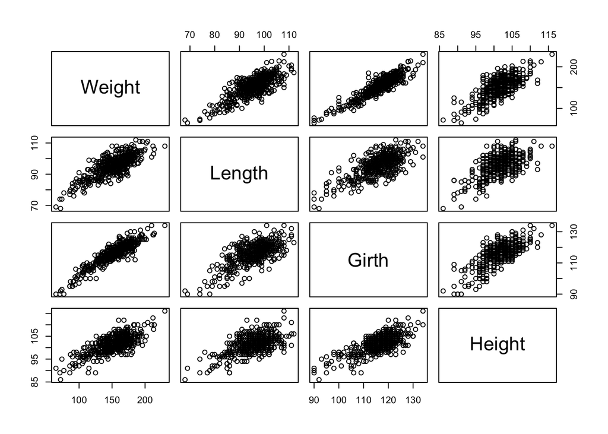

```r
pairs(Weight~Length + Girth + Height, data = train)
```

- Plots support use of linear model
- Let us try some transformations

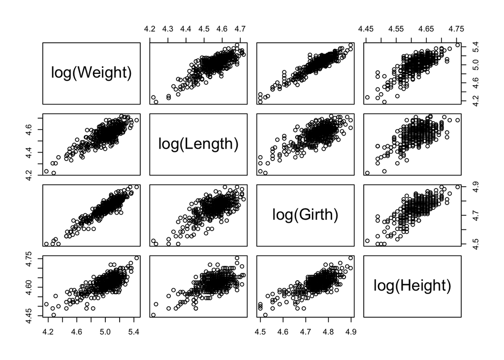

```r
pairs(log(Weight)~log(Length) + log(Girth) + log(Height), data = train)
```

- This motivates the use of log transforms

# Model 2

# Run model

```r
model.prop = lm(log(Weight) ~ BCS + Age + Sex + log(Length) + log(Girth) + log(Height), data=train)
summary(model.prop)
```

```
##
## Call:
## lm(formula = log(Weight) ~ BCS + Age + Sex + log(Length) + log(Girth) +
##     log(Height), data = train)
##
## Residuals:
##       Min        1Q    Median        3Q       Max
## -0.145380 -0.034821 -0.002462  0.037319  0.138669
##
## Coefficients:
##              Estimate Std. Error t value Pr(>|t|)
## (Intercept) -7.450099   0.361939 -20.584  < 2e-16 ***
## BCS2         0.039661   0.025898   1.531 0.126415
## BCS2.5       0.059392   0.024186   2.456 0.014467 *
## BCS3         0.091378   0.024230   3.771 0.000186 ***
## BCS3.5       0.123219   0.025617   4.810 2.11e-06 ***
## BCS4         0.148491   0.029569   5.022 7.58e-07 ***
## Age2-5       0.050317   0.011491   4.379 1.51e-05 ***
## Age>5        0.081807   0.012266   6.670 8.10e-11 ***
## Sexgelding  -0.007268   0.007777  -0.935 0.350531
## Sexfemale   -0.004895   0.005635  -0.869 0.385545
## log(Length)  0.609589   0.050143  12.157  < 2e-16 ***
## log(Girth)   1.507239   0.080368  18.754  < 2e-16 ***
## log(Height)  0.513236   0.095697   5.363 1.35e-07 ***
## ---
## Signif. codes:  0 '***' 0.001 '**' 0.01 '*' 0.05 '.' 0.1 ' ' 1
##
## Residual standard error: 0.05205 on 420 degrees of freedom
## Multiple R-squared:  0.9257, Adjusted R-squared:  0.9235
## F-statistic: 435.8 on 12 and 420 DF,  p-value: < 2.2e-16
```

```r
vif(model.prop) # Idea obtained from Wang, Xu, Zhang
```

```
##        BCS2      BCS2.5        BCS3      BCS3.5        BCS4      Age2-5
##    5.392376   17.825944   23.290026   10.339717    3.460470    3.179407
##       Age>5  Sexgelding   Sexfemale log(Length)  log(Girth) log(Height)
##    4.914833    1.279763    1.246928    2.280798    4.222527    2.394345
```

- We note that the beta values for sex is very low, and the p-values are relatively high. This gives us motivation to do variable selection.
- Height seems to be important
- We also note that BCS = 2 does not seem to be significant, and standard error is almost as large as the estimate.
- VIF values for BCS = 2.5 and BCS = 3 are above 10, this could indicate multicollinearity.
- Let us bin BCS = 1.5 with BCS = 2

```r
#Binned model
model.prop = lm(log(Weight) ~ BCS + Age + Sex + log(Length) + log(Girth) + log(Height), data=train_binned)
summary(model.prop)
```

```
##
## Call:
## lm(formula = log(Weight) ~ BCS + Age + Sex + log(Length) + log(Girth) +
##     log(Height), data = train_binned)
##
## Residuals:
##       Min        1Q    Median        3Q       Max
## -0.143693 -0.034886 -0.002716  0.037449  0.139096
##
## Coefficients:
##              Estimate Std. Error t value Pr(>|t|)
## (Intercept) -7.425812   0.362169 -20.504  < 2e-16 ***
## BCS2.5       0.026718   0.011409   2.342   0.0197 *
## BCS3         0.058558   0.011322   5.172 3.59e-07 ***
## BCS3.5       0.090236   0.013893   6.495 2.35e-10 ***
## BCS4         0.115516   0.020298   5.691 2.37e-08 ***
## Age2-5       0.051548   0.011481   4.490 9.22e-06 ***
## Age>5        0.082292   0.012281   6.701 6.67e-11 ***
## Sexgelding  -0.007761   0.007782  -0.997   0.3192
## Sexfemale   -0.005276   0.005638  -0.936   0.3500
## log(Length)  0.612659   0.050183  12.208  < 2e-16 ***
## log(Girth)   1.510591   0.080467  18.773  < 2e-16 ***
## log(Height)  0.508529   0.095801   5.308 1.80e-07 ***
## ---
## Signif. codes:  0 '***' 0.001 '**' 0.01 '*' 0.05 '.' 0.1 ' ' 1
##
## Residual standard error: 0.05213 on 421 degrees of freedom
## Multiple R-squared:  0.9252, Adjusted R-squared:  0.9233
## F-statistic: 473.7 on 11 and 421 DF,  p-value: < 2.2e-16
```

```r
vif(model.prop)
```

```
##      BCS2.5        BCS3      BCS3.5        BCS4      Age2-5       Age>5
##    3.953736    5.069389    3.031566    1.625511    3.163858    4.911562
##  Sexgelding   Sexfemale log(Length)  log(Girth) log(Height)
##    1.277566    1.244498    2.277153    4.219396    2.391875
```

- Note beta values outside of BCS are not changed significantly
- Values in BCS are changed because of a shift in the baseline category
- VIF values are much better, which provides support for this binning

# Model Selection

```r
stepwise = ols_step_both_aic(model.prop)
stepwise
```

```
##
##
##                                 Stepwise Summary
## -------------------------------------------------------------------------------
## Variable        Method        AIC        RSS     Sum Sq     R-Sq      Adj. R-Sq
## -------------------------------------------------------------------------------
## log(Girth)     addition    -1058.630    2.169    13.136    0.85830      0.85797
## log(Length)    addition    -1223.571    1.475    13.829    0.90363      0.90318
## BCS            addition    -1252.965    1.353    13.951    0.91160      0.91036
## Age            addition    -1290.044    1.230    14.074    0.91960      0.91809
## log(Height)    addition    -1318.152    1.148    14.157    0.92500      0.92341
## -------------------------------------------------------------------------------
```

```r
forward = ols_step_forward_aic(model.prop)
summary(forward$model)
```

```
##
## Call:
## lm(formula = paste(response, "~", paste(preds, collapse = " + ")),
##     data = l)
##
## Residuals:
##       Min        1Q    Median        3Q       Max
## -0.142302 -0.035275 -0.002376  0.036321  0.137105
##
## Coefficients:
##             Estimate Std. Error t value Pr(>|t|)
## (Intercept) -7.39971    0.35855 -20.638  < 2e-16 ***
## log(Girth)   1.49927    0.07978  18.793  < 2e-16 ***
## log(Length)  0.61005    0.04956  12.310  < 2e-16 ***
## BCS2.5       0.02610    0.01136   2.297   0.0221 *
## BCS3         0.05823    0.01131   5.150 4.01e-07 ***
## BCS3.5       0.08973    0.01388   6.466 2.78e-10 ***
## BCS4         0.11526    0.02027   5.686 2.42e-08 ***
## Age2-5       0.05309    0.01139   4.662 4.20e-06 ***
## Age>5        0.08302    0.01216   6.825 3.05e-11 ***
## log(Height)  0.51625    0.09354   5.519 5.96e-08 ***
## ---
## Signif. codes:  0 '***' 0.001 '**' 0.01 '*' 0.05 '.' 0.1 ' ' 1
##
## Residual standard error: 0.05209 on 423 degrees of freedom
## Multiple R-squared:  0.925,  Adjusted R-squared:  0.9234
## F-statistic: 579.7 on 9 and 423 DF,  p-value: < 2.2e-16
```

```r
backward = ols_step_backward_aic(model.prop)
summary(backward$model)
```

```
##
## Call:
## lm(formula = paste(response, "~", paste(preds, collapse = " + ")),
##     data = l)
##
## Residuals:
##       Min        1Q    Median        3Q       Max
## -0.142302 -0.035275 -0.002376  0.036321  0.137105
##
## Coefficients:
##             Estimate Std. Error t value Pr(>|t|)
## (Intercept) -7.39971    0.35855 -20.638  < 2e-16 ***
## BCS2.5       0.02610    0.01136   2.297   0.0221 *
## BCS3         0.05823    0.01131   5.150 4.01e-07 ***
## BCS3.5       0.08973    0.01388   6.466 2.78e-10 ***
## BCS4         0.11526    0.02027   5.686 2.42e-08 ***
## Age2-5       0.05309    0.01139   4.662 4.20e-06 ***
## Age>5        0.08302    0.01216   6.825 3.05e-11 ***
## log(Length)  0.61005    0.04956  12.310  < 2e-16 ***
## log(Girth)   1.49927    0.07978  18.793  < 2e-16 ***
## log(Height)  0.51625    0.09354   5.519 5.96e-08 ***
## ---
## Signif. codes:  0 '***' 0.001 '**' 0.01 '*' 0.05 '.' 0.1 ' ' 1
##
## Residual standard error: 0.05209 on 423 degrees of freedom
## Multiple R-squared:  0.925,  Adjusted R-squared:  0.9234
## F-statistic: 579.7 on 9 and 423 DF,  p-value: < 2.2e-16
```

- We see that indeed, sex is irrelevant. However, unlike the original paper, Height seems to be relevant.

# Model 3

# Run model

```r
#Remove Sex
model = lm(log(Weight) ~ BCS + Age + log(Length) + log(Girth) + log(Height), data=train_binned)
predictions = predict.lm(model, test_binned, interval="confidence")
our_predicted = exp(predictions[,1])
summary(model)
```

```
##
## Call:
## lm(formula = log(Weight) ~ BCS + Age + log(Length) + log(Girth) +
##     log(Height), data = train_binned)
##
## Residuals:
##       Min        1Q    Median        3Q       Max
## -0.142302 -0.035275 -0.002376  0.036321  0.137105
##
## Coefficients:
##             Estimate Std. Error t value Pr(>|t|)
## (Intercept) -7.39971    0.35855 -20.638  < 2e-16 ***
## BCS2.5       0.02610    0.01136   2.297   0.0221 *
## BCS3         0.05823    0.01131   5.150 4.01e-07 ***
## BCS3.5       0.08973    0.01388   6.466 2.78e-10 ***
## BCS4         0.11526    0.02027   5.686 2.42e-08 ***
## Age2-5       0.05309    0.01139   4.662 4.20e-06 ***
## Age>5        0.08302    0.01216   6.825 3.05e-11 ***
## log(Length)  0.61005    0.04956  12.310  < 2e-16 ***
## log(Girth)   1.49927    0.07978  18.793  < 2e-16 ***
## log(Height)  0.51625    0.09354   5.519 5.96e-08 ***
## ---
## Signif. codes:  0 '***' 0.001 '**' 0.01 '*' 0.05 '.' 0.1 ' ' 1
##
## Residual standard error: 0.05209 on 423 degrees of freedom
## Multiple R-squared:  0.925,  Adjusted R-squared:  0.9234
## F-statistic: 579.7 on 9 and 423 DF,  p-value: < 2.2e-16
```

```r
confint(model)
```

```
##                    2.5 %      97.5 %
## (Intercept) -8.104472947 -6.69494737
## BCS2.5       0.003766267  0.04843413
## BCS3         0.036003808  0.08045481
## BCS3.5       0.062451702  0.11700030
## BCS4         0.075421180  0.15510641
## Age2-5       0.030708738  0.07547428
## Age>5        0.059112755  0.10693114
## log(Length)  0.512640747  0.70745329
## log(Girth)   1.342454558  1.65608202
## log(Height)  0.332387364  0.70011822
```

- Height is still important
- We also note that we get $\beta_{10} = 0.610, \beta_{11} = 1.50$, which are not equal to our idealized model, but close. This could indicate a cylinder with a “fatter” center, and a more ellipsoidal body.

# Diagnostics

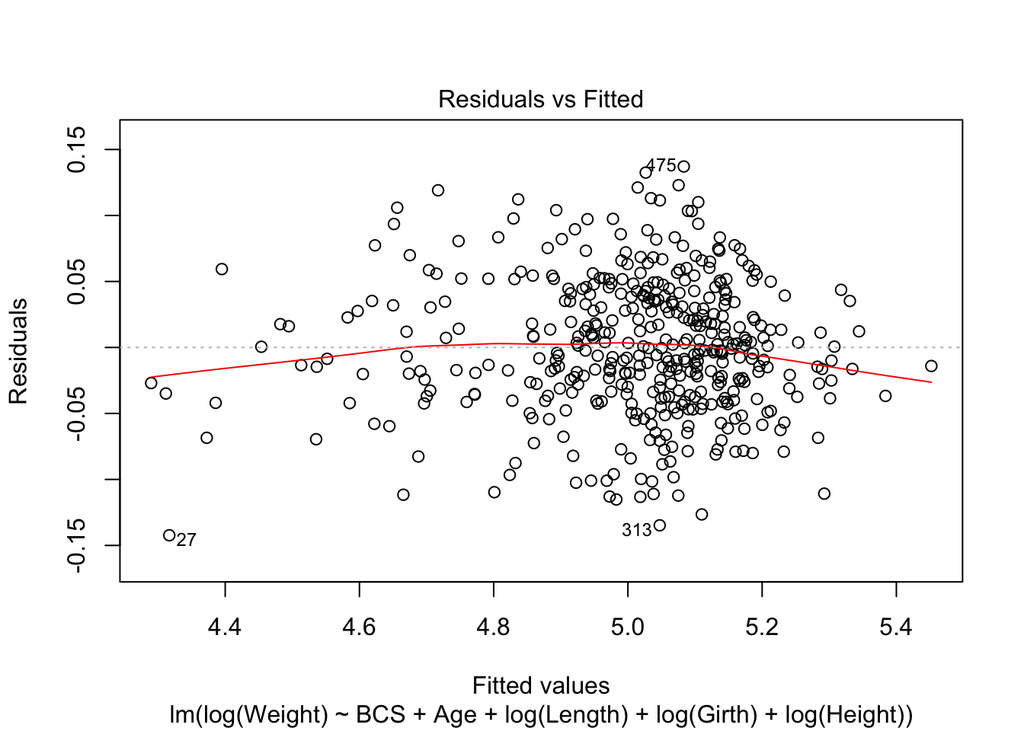

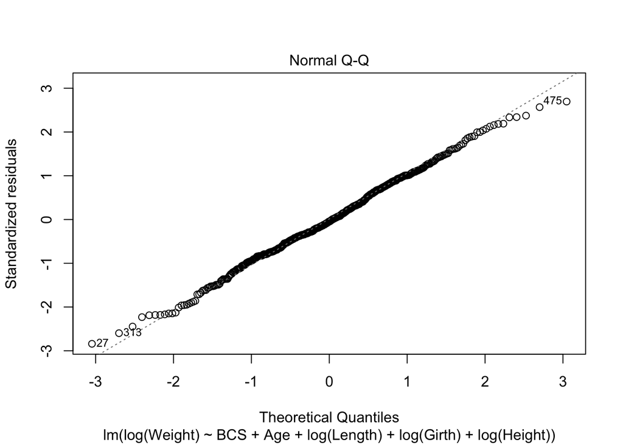

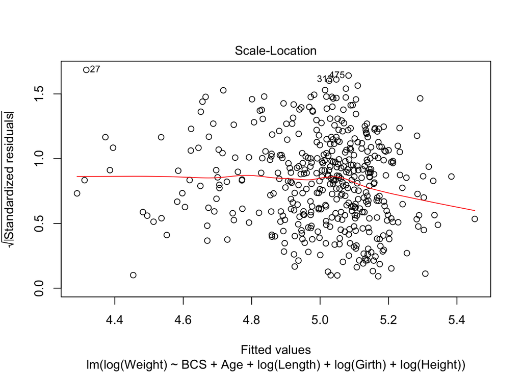

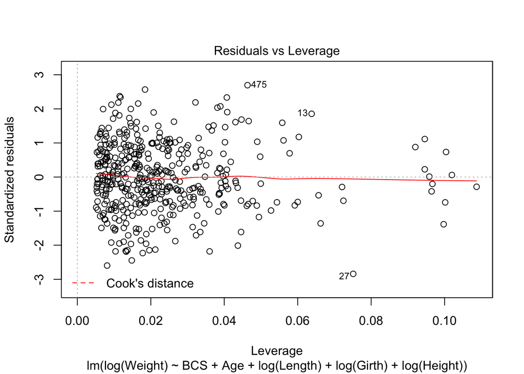

```r
plot(model)
```

- Everything looks good.

# Fit to Test

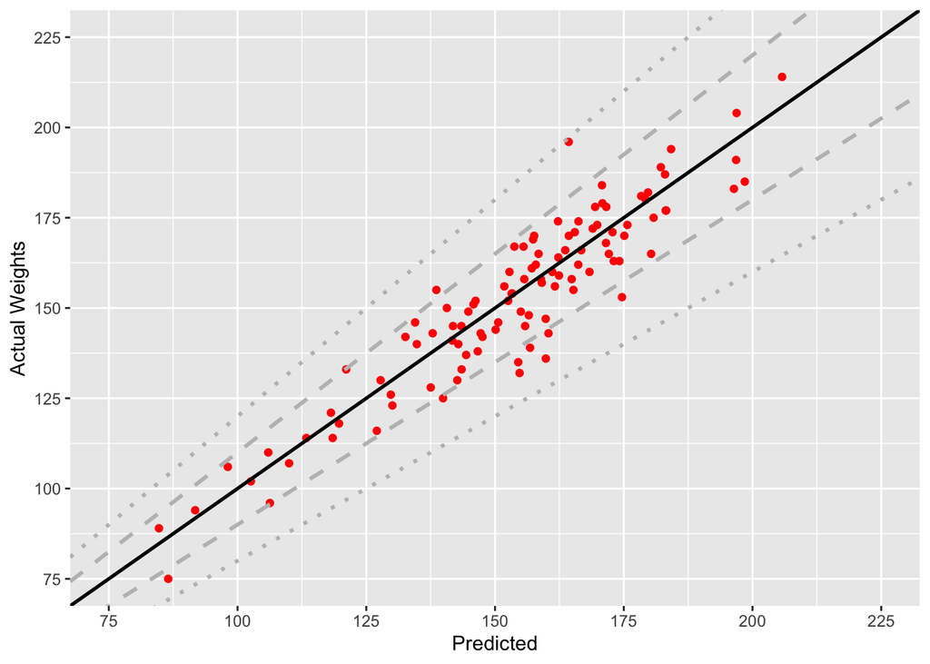

```r
#Plot Actual weights vs predicted
plot_predictions(our_predicted)
```

```r
# Get Mean Squared Error and Mean Relative Squared Error
results <- function(predicted, actual){
  residuals = predicted - actual
  relative_error = predicted/actual
  MSE = mean(residuals^2)
  cat("The MSE is", MSE,'\n')
  cat("The Mean Relative Squared Error is",mean((relative_error-1)^2),'\n\n')
}
```

```r
results(our_predicted,test_binned$Weight)
```

```
## The MSE is 85.67837
## The Mean Relative Squared Error is 0.003974487
```

```r
sqrt(85.67837)
```

```
## [1] 9.256261
```

```r
sqrt(0.003974487)
```

```
## [1] 0.06304353
```

# Test for Interactions

```r
donkeys_binned_log = subset(donkeys_binned, select = -c(WeightAlt))
donkeys_binned_log$Length = log(donkeys_binned_log$Length)
donkeys_binned_log$Weight = log(donkeys_binned_log$Weight)
donkeys_binned_log$Height = log(donkeys_binned_log$Height)
donkeys_binned_log$Girth = log(donkeys_binned_log$Girth)

names(donkeys_binned_log)[names(donkeys_binned_log) == "Length"] <- "logLength"
names(donkeys_binned_log)[names(donkeys_binned_log) == "Weight"] <- "logWeight"
names(donkeys_binned_log)[names(donkeys_binned_log) == "Height"] <- "logHeight"
names(donkeys_binned_log)[names(donkeys_binned_log) == "Girth"] <- "logGirth"
# We note that this data still includes Sex information
```

```r
train_binned_log <- NULL
test_binned_log <- NULL

for(i in 1:nrow(donkeys)){
  if (mod(i,5) == 0){
    test_binned_log <- rbind(test_binned_log, donkeys_binned_log[i,])
  }
  else{
    train_binned_log <- rbind(train_binned_log, donkeys_binned_log[i,])
  }
}
```

```r
# 2-way interactions
model.2nd = lm(logWeight~ .^2, data=train_binned_log)
# 3-way interactions
model.3rd = lm(logWeight~ .^3, data=train_binned_log)

# Adding up to 2nd order polynomial terms
model_poly_2nd = lm( logWeight ~ Age + Sex + BCS + logLength + logHeight + logGirth + logLength*logHeight + logHeight*logGirth + logLength*logHeight + I(logLength ^ 2) + I(logHeight^2) + I(logGirth^2), data=train_binned_log)

# Adding up to 3rd order polynomial terms
model_poly_3rd = lm(logWeight ~ Age + Sex + BCS + logLength + logHeight + logGirth + logLength*logHeight + logHeight*logGirth + logLength*logHeight + I(logLength^2) + I(logHeight^2) + I(logGirth^2) + I(logLength^2*logHeight) + I(logLength^2*logGirth) + I(logHeight^2*logLength) + I(logHeight^2*logGirth) + I(logGirth^2*logLength) + I(logGirth^2*logHeight) + I(logLength^3) + I(logHeight^3) + I(logGirth^3), data=train_binned_log)
```

```r
# Conduct backward selection
backward_2nd = ols_step_backward_aic(model.2nd)
backward_3rd = ols_step_backward_aic(model.3rd)
backward_poly_2nd = ols_step_backward_aic(model_poly_2nd)
backward_poly_3rd = ols_step_backward_aic(model_poly_3rd)
```

```r
# See variables selected
names(backward_2nd$model$coefficients)
```

```
##  [1] "(Intercept)"        "Age2-5"             "Age>5"
##  [4] "logHeight"          "BCS1.5/2:logLength" "BCS2.5:logLength"
##  [7] "BCS3:logLength"     "BCS3.5:logLength"   "BCS4:logLength"
## [10] "Age2-5:logHeight"   "Age>5:logHeight"    "logLength:logGirth"
## [13] "logHeight:logGirth"
```

```r
names(backward_3rd$model$coefficients)
```

```
##  [1] "(Intercept)"                "BCS2.5"
##  [3] "BCS3"                       "BCS3.5"
##  [5] "BCS4"                       "logLength"
##  [7] "logHeight"                  "logLength:Age2-5"
##  [9] "logLength:Age>5"            "logHeight:Age2-5"
## [11] "logHeight:Age>5"            "logLength:logGirth"
## [13] "logLength:Age2-5:logGirth"  "logLength:Age>5:logGirth"
## [15] "logLength:logHeight:Age<2"  "logLength:logHeight:Age2-5"
## [17] "logLength:logHeight:Age>5"  "logHeight:Age<2:logGirth"
## [19] "logHeight:Age2-5:logGirth"  "logHeight:Age>5:logGirth"
```

```r
names(backward_poly_2nd$model$coefficients)
```

```
##  [1] "(Intercept)"    "Age2-5"         "Age>5"          "BCS2.5"
##  [5] "BCS3"           "BCS3.5"         "BCS4"           "logLength"
##  [9] "logHeight"      "logGirth"       "I(logLength^2)" "I(logHeight^2)"
## [13] "I(logGirth^2)"
```

```r
names(backward_poly_3rd$model$coefficients)
```

```
##  [1] "(Intercept)"               "Age2-5"
##  [3] "Age>5"                     "BCS2.5"
##  [5] "BCS3"                      "BCS3.5"
##  [7] "BCS4"                      "logLength"
##  [9] "I(logHeight^2)"            "I(logGirth^2)"
## [11] "I(logLength^2 * logGirth)" "I(logHeight^2 * logGirth)"
## [13] "I(logGirth^2 * logLength)" "I(logGirth^2 * logHeight)"
## [15] "I(logLength^3)"            "I(logHeight^3)"
## [17] "logHeight:logGirth"
```

- Note that all models include Height, but none have Sex.

# Cross-Validation

```r
MSEs_model = c()
MRSEs_model = c()
MSEs_backward_2nd = c()
MRSEs_backward_2nd = c()
MSEs_backward_3rd = c()
MRSEs_backward_3rd = c()
MSEs_backward_poly_2nd = c()
MRSEs_backward_poly_2nd = c()
MSEs_backward_poly_3rd = c()
MRSEs_backward_poly_3rd = c()

store_results <- function(model,test_fold){
  predictions = predict.lm(model, test_fold, interval="confidence")
  residuals = exp(predictions[,1]) - exp(test_fold$logWeight)
  MSE = mean(residuals^2)
  relative_error = exp(predictions[,1])/exp(test_fold$logWeight)
  MRSE = (mean((relative_error-1)^2))
  return(c(MSE,MRSE))
}

for(i in 1:5){

  # split into train and test folds
  test_indices = seq(i, nrow(donkeys_binned_log), 5)
  train_fold = donkeys_binned_log[-test_indices,]
  test_fold = donkeys_binned_log[test_indices,]

  #create a new model on train_fold
  our_model = lm(logWeight ~ BCS + Age + logLength + logGirth + logHeight, data=train_fold)
  backward_2nd = lm(logWeight ~ Age + logHeight +BCS*logLength + Age*logHeight + logLength*logGirth + logHeight*logGirth, data=train_fold)
  backward_3rd = lm(logWeight ~ BCS + logLength + logHeight + logLength*Age + logHeight*Age + logLength*logGirth + logLength*Age*logGirth + logLength*logHeight*Age + logHeight*logGirth*Age, data=train_fold)
  backward_poly_2nd = lm(logWeight ~ Age + BCS + logLength + logHeight + logGirth + I(logLength^2) + I(logHeight^2) + I(logGirth^2), data=train_fold)
  backward_poly_3rd = lm(logWeight ~ BCS + Age + logLength + logHeight*logGirth + I(logHeight^2) + I(logGirth^2) + I(logLength^2 * logGirth) + I(logHeight^2 * logGirth) + I(logGirth^2 * logLength) + I(logGirth^2 * logHeight) + I(logHeight^3) + I(logLength^3), data=train_fold)

  MSEs_model = c(MSEs_model, store_results(our_model,test_fold)[1])
  MRSEs_model = c(MRSEs_model, store_results(our_model,test_fold)[2])
  MSEs_backward_2nd = c(MSEs_backward_2nd, store_results(backward_2nd,test_fold)[1])
  MRSEs_backward_2nd = c(MRSEs_backward_2nd, store_results(backward_2nd,test_fold)[2])
  MSEs_backward_3rd = c(MSEs_backward_3rd, store_results(backward_3rd,test_fold)[1])
  MRSEs_backward_3rd = c(MRSEs_backward_3rd, store_results(backward_3rd,test_fold)[2])
  MSEs_backward_poly_2nd = c(MSEs_backward_poly_2nd, store_results(backward_poly_2nd,test_fold)[1])
  MRSEs_backward_poly_2nd = c(MRSEs_backward_poly_2nd, store_results(backward_poly_2nd,test_fold)[2])
  MSEs_backward_poly_3rd = c(MSEs_backward_poly_3rd, store_results(backward_poly_3rd,test_fold)[1])
  MRSEs_backward_poly_3rd = c(MRSEs_backward_poly_3rd, store_results(backward_poly_3rd,test_fold)[2])
}
```

```r
display_result <- function(vec, text){
  cat("The mean", text, "is", mean(vec), "with standard deviation", sd(vec), "\n")
}
```

```r
display_result(MSEs_model,"MSE of our model")
```

```
## The mean MSE of our model is 67.29748 with standard deviation 12.13421
```

```r
display_result(MSEs_backward_2nd,"MSE of pairwise interactions")
```

```
## The mean MSE of pairwise interactions is 66.86493 with standard deviation 11.29709
```

```r
display_result(MSEs_backward_3rd,"MSE of three-way interactions")
```

```
## The mean MSE of three-way interactions is 69.85414 with standard deviation 11.65594
```

```r
display_result(MSEs_backward_poly_2nd,"MSE of 2nd order polynomial terms")
```

```
## The mean MSE of 2nd order polynomial terms is 65.9575 with standard deviation 11.86272
```

```r
display_result(MSEs_backward_poly_3rd,"MSE of 3rd order polynomial terms")
```

```
## The mean MSE of 3rd order polynomial terms is 68.42162 with standard deviation 12.49041
```

```r
display_result(MRSEs_model,"MRSE of our model")
```

```
## The mean MRSE of our model is 0.003015739 with standard deviation 0.0005676491
```

```r
display_result(MRSEs_backward_2nd,"MRSE of pairwise interactions")
```

```
## The mean MRSE of pairwise interactions is 0.002965627 with standard deviation 0.0005961732
```

```r
display_result(MRSEs_backward_3rd,"MRSE of three-way interactions")
```

```
## The mean MRSE of three-way interactions is 0.00327348 with standard deviation 0.0007043848
```

```r
display_result(MRSEs_backward_poly_2nd,"MRSE of 2nd order polynomial terms")
```

```
## The mean MRSE of 2nd order polynomial terms is 0.002966299 with standard deviation 0.0006086333
```

```r
display_result(MRSEs_backward_poly_3rd,"MRSE of 3rd order polynomial terms")
```

```
## The mean MRSE of 3rd order polynomial terms is 0.003068487 with standard deviation 0.0006117016
```

```r
model_poly_2nd = lm(log(Weight) ~ BCS + Age + log(Length) + log(Girth) + log(Height) + I(log(Length)^2) + I(log(Girth)^2) + I(log(Height)^2), data=train_binned)
summary(model_poly_2nd)
```

```
##
## Call:
## lm(formula = log(Weight) ~ BCS + Age + log(Length) + log(Girth) +
##     log(Height) + I(log(Length)^2) + I(log(Girth)^2) + I(log(Height)^2),
##     data = train_binned)
##
## Residuals:
##       Min        1Q    Median        3Q       Max
## -0.137151 -0.033130  0.000032  0.033909  0.133576
##
## Coefficients:
##                   Estimate Std. Error t value Pr(>|t|)
## (Intercept)       -7.28041   20.32197  -0.358 0.720334
## BCS2.5             0.02099    0.01127   1.862 0.063324 .
## BCS3               0.05617    0.01117   5.027 7.38e-07 ***
## BCS3.5             0.09269    0.01369   6.768 4.40e-11 ***
## BCS4               0.12502    0.02037   6.138 1.93e-09 ***
## Age2-5             0.03988    0.01193   3.343 0.000904 ***
## Age>5              0.07254    0.01247   5.819 1.18e-08 ***
## log(Length)        7.03053    3.35430   2.096 0.036682 *
## log(Girth)        12.01234    5.15072   2.332 0.020164 *
## log(Height)      -16.57399   10.43352  -1.589 0.112918
## I(log(Length)^2)  -0.70722    0.36858  -1.919 0.055691 .
## I(log(Girth)^2)   -1.11488    0.54418  -2.049 0.041107 *
## I(log(Height)^2)   1.85064    1.12940   1.639 0.102044
## ---
## Signif. codes:  0 '***' 0.001 '**' 0.01 '*' 0.05 '.' 0.1 ' ' 1
##
## Residual standard error: 0.05132 on 420 degrees of freedom
## Multiple R-squared:  0.9277, Adjusted R-squared:  0.9257
## F-statistic: 449.3 on 12 and 420 DF,  p-value: < 2.2e-16
```

- We see that the beta values associated with log(Length) and log(Girth) are around 7 and 12, which is also hard to understand biologically.
- We hence continue with our original model.

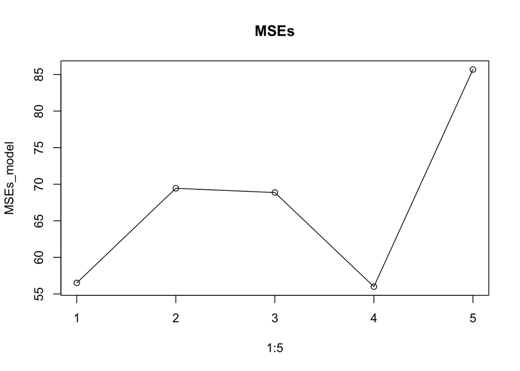

```r
plot(1:5, MSEs_model, type="o", main="MSEs")
```

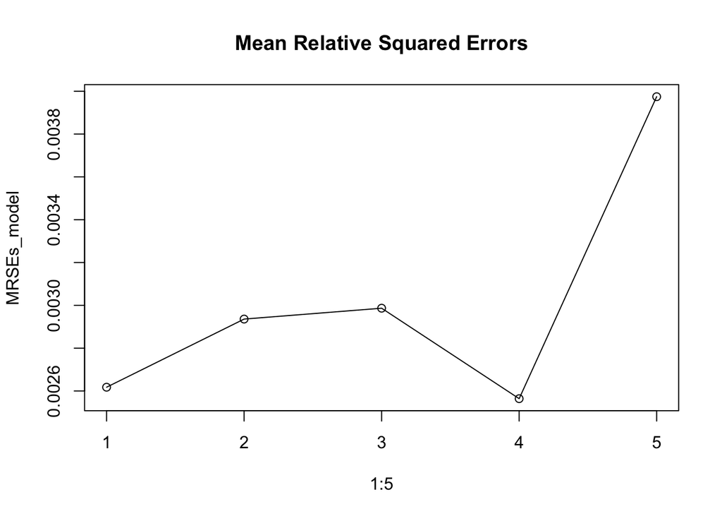

```r
plot(1:5, MRSEs_model, type="o", main = "Mean Relative Squared Errors")
```

- We are unable to perform cross-validation on authors’ model because we cannot recover loss function
- Cross-validation shows that our model performs even better on other folds.

# Comparison with Model 1

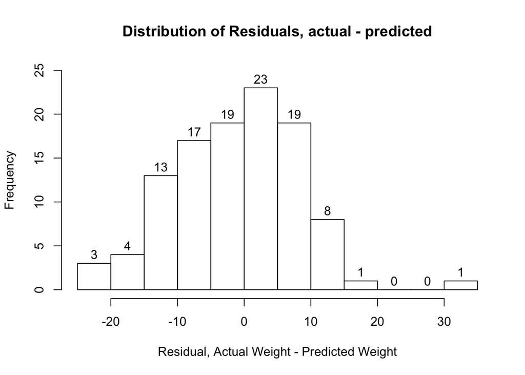

```r
#Compare distributions of residuals
plot_hist_residuals(our_predicted, test$Weight, 16)
```

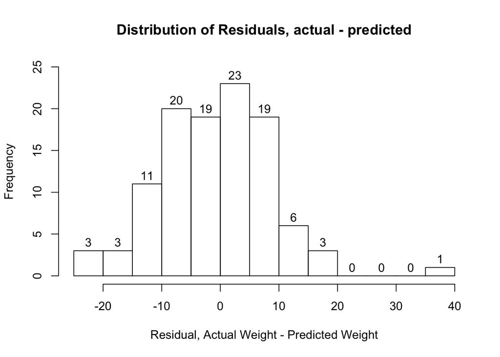

```r
plot_hist_residuals(author_predicted, test$Weight, 16)
```

- Looking at the absolute difference of actual and predicted weight, our model has slightly smaller under-predictions and slightly larger over-predictions. This is expected because our model uses a symmetric loss function. But it might be concerning.

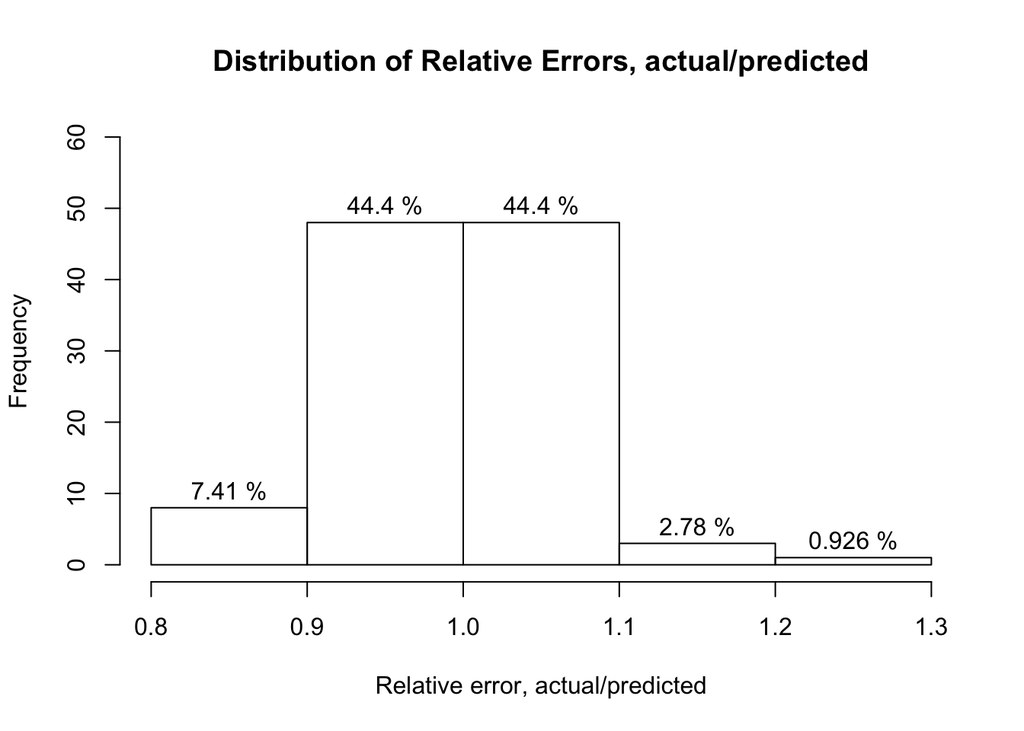

```r
#Compare distributions of relative errors
plot_hist(author_predicted, test$Weight)
```

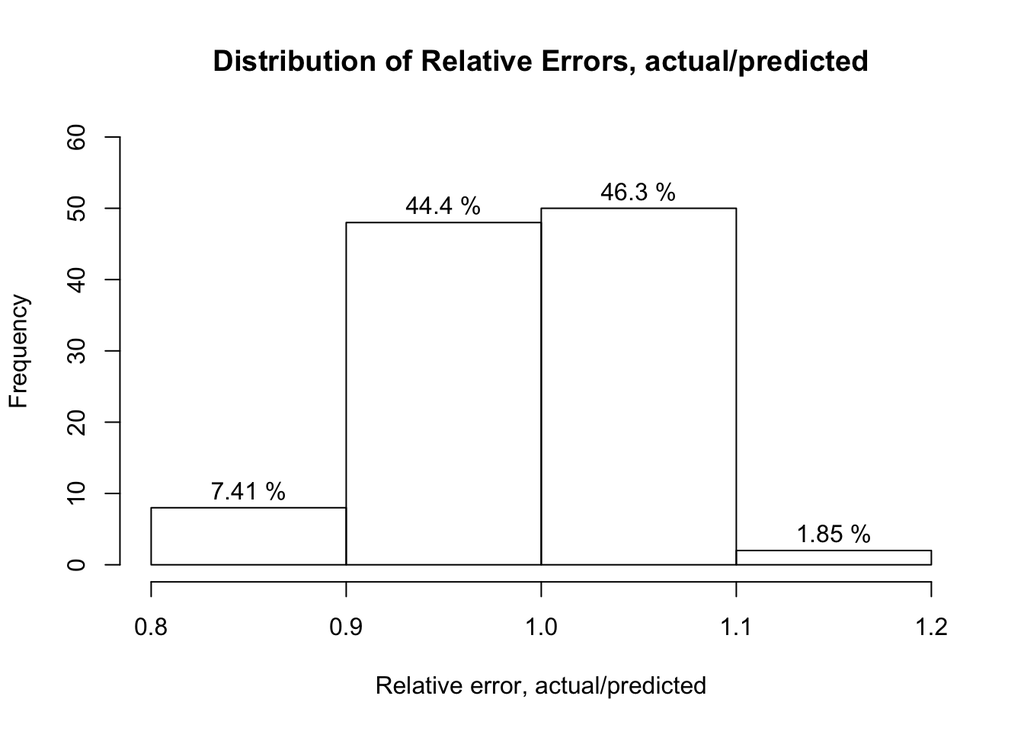

```r
plot_hist(our_predicted, test_binned$Weight)
```

- However, error as in Milner and Rougier is defined on a relative error. Doing so, we see that our model seems to over-predict the same and have fewer under-predictions.

```r
#Compare MSE and MRSE
results(author_predicted,test$Weight)
```

```
## The MSE is 90.87717
## The Mean Relative Squared Error is 0.004186922
```

```r
results(our_predicted,test_binned$Weight)
```

```
## The MSE is 85.67837
## The Mean Relative Squared Error is 0.003974487
```

- We note a modest reduction in MSE, and a slight reduction in relative error too. Our model is comparable/better than the given model, using a symmetric loss.

# What about our performance on their loss function?

- We are unable to reproduce their loss function exactly, but we can try to approximate it

```r
#First transform the variables and store data in X, target variable is y
n = nrow(train_reproducing)
X <- matrix(NA, nrow = n, ncol = 3)
X[,1] <- rep(1,n) #Intercept
X[,2] <- log(train_reproducing$Length)
X[,3] <- log(train_reproducing$Girth)
y <- 2*(sqrt(train_reproducing$Weight) - 1)
theta<-c (-103.394,8.057,18.837) #Initialize base on ols values
```

```r
# Define scaled quad-quad loss function that weights negative residuals greater
# We do not implement a tilt as mentioned in the paper, as this would require optimizing over too many hyperparameters

new_cost<-function(X, y, par, alpha){
  predictions = X%*%par
  relative_error = y/predictions - 1 #Note we use actual/predicted as per Miler and Rougier
  for (i in 1:length(relative_error)){
    if(relative_error[i]<0){
      relative_error[i]=relative_error[i]*alpha #Weight negative relative error
    }
  }
  J <- sum((relative_error)^2)
  return(J)
}
```

```r
# We search for the optimal value that we weight the negative residuals by
alphas = seq(1,2.5,by=0.01)
differences = c()
optimal = c(-107.0, 7.712, 19.91)

for(i in 1:length(alphas)){
  ret = optim(par = theta, fn = new_cost, X = X, y = y, alpha = alphas[i]) #We use an optimizer to solve for beta values given the loss function
  difference = sum(abs(ret$par - optimal)) #We take the difference between the beta values we obtain and the values in the paper
  differences[i] = difference
}

alpha = alphas[which.min(differences)]
print(alpha) #Negative relative errors are weighted by alpha^2
```

```
## [1] 2.14
```

```r
ret = optim(par = theta, fn = new_cost, X = X, y = y, alpha = alpha)
print(ret$par) #Beta values we obtain with this alpha
```

```
## [1] -106.995587    8.055904   19.505714
```

- Our beta estimates are close to that reported in Milner and Rougier’s paper.

```r
#We define the asymmetric loss function
asymmetric_loss <- function(predicted, actual, alpha){
  relative_error = actual/predicted-1
  for (i in 1:length(relative_error)){
    if(relative_error[i]<0){
      relative_error[i]=relative_error[i]*alpha
    }
  }
  cat("The Asymmetric Loss is",mean((relative_error)^2),"\n")
}
```

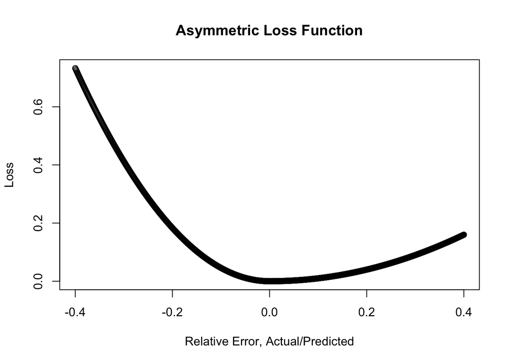

```r
# Generic Asymmetric Loss
asymm_func <- function(x, alpha){
  if(x < 0){
    return(alpha^2*x^2)
  }
  return(x^2)
}

# We plot our Asymmetric Loss function.
x <- seq(-0.4,0.4,0.001)
Loss <- lapply(x, asymm_func, alpha)

plot(x,Loss, xlab = "Relative Error, Actual/Predicted",  main = "Asymmetric Loss Function")
```

```r
asymmetric_loss(author_predicted, test$Weight, alpha)
```

```
## The Asymmetric Loss is 0.01196176
```

```r
asymmetric_loss(our_predicted, test_binned$Weight, alpha)
```

```
## The Asymmetric Loss is 0.0116219
```

- As expected, our model does perform better under the asymmetric loss.
- We could train our model with this loss, as shown below.

# Train Model with Asymmetric Loss

```r
# Transform factor variables into extra columns
BCS2.5 = sapply(donkeys_binned$BCS==2.5, as.numeric)
BCS3.0 = sapply(donkeys_binned$BCS==3.0, as.numeric)
BCS3.5 = sapply(donkeys_binned$BCS==3.5, as.numeric)
BCS4.0 = sapply(donkeys_binned$BCS==4.0, as.numeric)
Age25 = sapply(donkeys_binned$Age == "2-5", as.numeric)
Ageover5 = sapply(donkeys_binned$Age == ">5", as.numeric)
donkeys_binned = cbind(donkeys_binned,BCS2.5, BCS3.0, BCS3.5, BCS4.0, Age25, Ageover5)
```

```r
# Reobtain train and test splits
train_asymm <- NULL
test_asymm <- NULL
for(i in 1:nrow(donkeys_binned)){
  if (mod(i,5) == 0){
    test_asymm <- rbind(test_asymm, donkeys_binned[i,])
  }
  else{
    train_asymm <- rbind(train_asymm, donkeys_binned[i,])
  }
}
```

```r
# Transform training data into a numeric matrix
n = nrow(train_asymm)
X <- matrix(NA, nrow = n, ncol = 10)
X[,1] <- rep(1,n) #Intercept
X[,2:7] <- as.matrix(train_asymm[,9:14])
X[,8] <- log(train_asymm$Length)
X[,9] <- log(train_asymm$Girth)
X[,10] <- log(train_asymm$Height)
y <- train_asymm$Weight
theta<-c(model$coefficients) # Initialize theta with our estimates from the ols solution
```

```r
# Transform testing data into a numeric matrix
n = nrow(test_asymm)
X_test <- matrix(NA, nrow = n, ncol = 10)
X_test[,1] <- rep(1,n) #Intercept
X_test[,2:7] <- as.matrix(test_asymm[,9:14])
X_test[,8] <- log(test_asymm$Length)
X_test[,9] <- log(test_asymm$Girth)
X_test[,10] <- log(test_asymm$Height)
```

```r
# Define asymmetric cost function
new_cost<-function(X, y, par, alpha){
  predictions = exp(X%*%par)
  relative_error = y/predictions - 1 #Note we use actual/predicted as per Miler and Rougier
  for (i in 1:length(relative_error)){
    if(relative_error[i]<0){
      relative_error[i]=relative_error[i]*alpha #Weight negative relative error
    }
  }
  J <- sum((relative_error)^2)
  return(J)
}
```

```r
#Obtain new beta values
ret = optim(par = theta, fn = new_cost, X = X, y = y, alpha = alpha)
print(ret$par)
```

```
## (Intercept)      BCS2.5        BCS3      BCS3.5        BCS4      Age2-5
## -7.39178627  0.02443961  0.05351979  0.09600824  0.12078522  0.05379566
##       Age>5 log(Length)  log(Girth) log(Height)
##  0.08503580  0.60818453  1.51149572  0.49821667
```

```r
print(model$coefficients)
```

```
## (Intercept)      BCS2.5        BCS3      BCS3.5        BCS4      Age2-5
## -7.39971016  0.02610020  0.05822931  0.08972600  0.11526380  0.05309151
##       Age>5 log(Length)  log(Girth) log(Height)
##  0.08302195  0.61004702  1.49926829  0.51625279
```

- We note that when the model is trained under asymmetric loss, the beta values do not change significantly.

```r
# Obtain results for model trained under asymmetric loss
predictions = exp(X_test%*%(ret$par))
asymmetric_loss(predictions, test_asymm$Weight, alpha)
```

```
## The Asymmetric Loss is 0.008365985
```

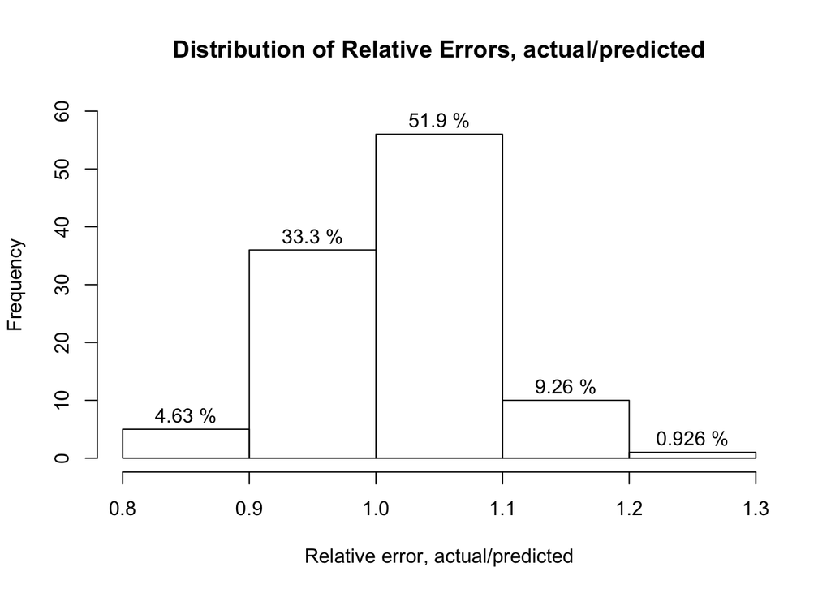

```r
plot_hist(predictions, test_asymm$Weight)
```

```r
results(predictions,test$Weight)
```

```
## The MSE is 93.27277
## The Mean Relative Squared Error is 0.003937134
```

- Asymmetric loss on the test data is lower, as expected.
- This indicates that our given model is more flexible. While we do not know the loss function exactly, it is likely that once known, our model can be trained to perform better than the Milner-Rougier model.
- However, the MSE is greater.
- The histogram shows how relative error (a/p) is now skewed toward postive relative errors (a/p).
- Without full knowledge of the level of asymmetry, we shall revert to our original model, since the difference in betas is not especially significant, we can benefit from confidence intervals from the ols solution, and it might be unwise to skew our predictions without more knowledge of the loss function.
- Loss functions for model training can be changed flexibly. We shall demonstrate again with L1 loss later.

## Check Summing Assumption

```r
min(test$Weight/author_predicted - 1) #Minimum relative error (a/p) on training set, Model 1
```

```
## [1] -0.1507477
```

```r
min(test$Weight/predictions-1) #Minimum relative error (a/p) on training set, Model 3
```

```
## [1] -0.1241033
```

- The proposed model seems to penalize overdosing more than the function used in Milner and Rougier.
- Hence, even if Milner and Rougier did not add their two loss functions together, doing so does not seem to encourage over-dosage significantly.

# Training with L1 Loss

```r
L1_cost<-function(X, y, par){
  predictions = X%*%par
  J <- sum(abs(log(y) - predictions))
  return(J)
}
```

```r
ret = optim(par = theta, fn = L1_cost, X = X, y = y)
print(ret$par) # New Beta Values
```

```
## (Intercept)      BCS2.5        BCS3      BCS3.5        BCS4      Age2-5
## -7.39877994  0.04445598  0.07786441  0.09847009  0.13544889  0.06444952
##       Age>5 log(Length)  log(Girth) log(Height)
##  0.09031242  0.61003815  1.48997269  0.51995147
```

```r
print(model$coefficients)
```

```
## (Intercept)      BCS2.5        BCS3      BCS3.5        BCS4      Age2-5
## -7.39971016  0.02610020  0.05822931  0.08972600  0.11526380  0.05309151
##       Age>5 log(Length)  log(Girth) log(Height)
##  0.08302195  0.61004702  1.49926829  0.51625279
```

```r
predictions = exp(X_test%*%(ret$par))
results(predictions,test_binned$Weight) #Get results for new model
```

```
## The MSE is 86.92027
## The Mean Relative Squared Error is 0.004016107
```

```r
asymmetric_loss(predictions,test_binned$Weight,alpha)
```

```
## The Asymmetric Loss is 0.01166026
```

- L1 Loss shows greater MSE, MRSE, and Asymmetric Loss than our model.

# Baby Donkey

```r
# We suspect that our model might extend better to out of data samples, especially for baby donkeys.
our_prediction = exp(predict.lm(model, baby)[1])
f = -107 + 19.91*log(baby$Girth)
g = 7.712*log(baby$Length)
raw_weight = (((f+g)/2) + 1)^2
age = sapply(as.numeric(baby$Age),age_adjustment)
bcs = sapply(as.numeric(baby$BCS),bcs_adjustment)
author_prediction = raw_weight + age + bcs
cat("The baby donkey weighs", baby$Weight, 'kg. \n')
```

```
## The baby donkey weighs 27 kg.
```

```r
cat("Milner and Rougier's model predicts", author_prediction, 'kg. \n')
```

```
## Milner and Rougier's model predicts 7.77086 kg.
```

```r
cat("Our model predicts", our_prediction, 'kg. \n')
```

```
## Our model predicts 32.33685 kg.
```

# Sensitivity Analysis

- Motivated by the EDA, we fit a linear model and notice that we get the same covariates that are important.

```r
model = lm(Weight ~ BCS + Age + Sex + Length + Girth + Height, data=train_binned)

stepwise = ols_step_both_aic(model)
stepwise
```

```
##
##
##                                   Stepwise Summary
## -----------------------------------------------------------------------------------
## Variable     Method       AIC          RSS         Sum Sq       R-Sq      Adj. R-Sq
## -----------------------------------------------------------------------------------
## Girth       addition    3271.246    47755.264    242024.764    0.83520      0.83482
## Length      addition    3134.002    34622.690    255157.337    0.88052      0.87997
## BCS         addition    3076.437    29757.772    260022.256    0.89731      0.89586
## Height      addition    3048.198    27750.501    262029.527    0.90424      0.90266
## Age         addition    3022.634    25919.006    263861.022    0.91056      0.90865
## -----------------------------------------------------------------------------------
```

- We fit something similar to their model and notice the same thing

```r
model = lm(sqrt(Weight) ~ BCS + Age + Sex + log(Length) + log(Girth) + log(Height), data=train_binned)

stepwise = ols_step_both_aic(model)
stepwise
```

```
##
##
##                                 Stepwise Summary
## -------------------------------------------------------------------------------
## Variable        Method       AIC       RSS      Sum Sq      R-Sq      Adj. R-Sq
## -------------------------------------------------------------------------------
## log(Girth)     addition    493.087    78.083    439.692    0.84920      0.84885
## log(Length)    addition    347.442    55.523    462.253    0.89277      0.89227
## BCS            addition    296.606    48.468    469.307    0.90639      0.90507
## log(Height)    addition    270.709    45.444    472.331    0.91223      0.91079
## Age            addition    239.247    41.871    475.905    0.91913      0.91741
## -------------------------------------------------------------------------------
```

- We try a naive model that adds a term for the cylinder

```r
model = lm(Weight ~ BCS + Age + Sex + Length + Girth + Height + Length*Girth^2, data=train_binned)

stepwise = ols_step_both_aic(model)
stepwise
```

```
##
##
##                                     Stepwise Summary
## ---------------------------------------------------------------------------------------
## Variable         Method       AIC          RSS         Sum Sq       R-Sq      Adj. R-Sq
## ---------------------------------------------------------------------------------------
## Length:Girth    addition    3253.791    45868.433    243911.594    0.84171      0.84135
## Girth           addition    3128.635    34196.232    255583.796    0.88199      0.88144
## BCS             addition    3076.624    29770.617    260009.411    0.89726      0.89582
## Height          addition    3047.893    27730.913    262049.115    0.90430      0.90273
## Age             addition    3018.761    25688.217    264091.811    0.91135      0.90947
## ---------------------------------------------------------------------------------------
```

- All models show that we should not consider Sex, but Height seems to be important.

# Interpretation of betas

```r
#Reset model
model = lm(log(Weight) ~ BCS + Age + log(Length) + log(Girth) + log(Height), data=train_binned)
```

```r
length_quantiles = quantile(donkeys$Length,probs = c(0.025, 0.5, 0.975))
girth_quantiles = quantile(donkeys$Girth,probs = c(0.025, 0.5, 0.975))
height_quantiles = quantile(donkeys$Height,probs = c(0.025, 0.5, 0.975))
```

```r
beta_7 = model$coefficients[8]
beta_8 = model$coefficients[9]
beta_9 = model$coefficients[10]
```

```r
# Obtain changes to weight with 1cm change in numeric variables
(((length_quantiles+1)^beta_7)/(length_quantiles^beta_7)-1)*100
```

```
##      2.5%       50%     97.5%
## 0.7654837 0.6276563 0.5638429
```

```r
(((girth_quantiles+1)^beta_8)/(girth_quantiles^beta_8)-1)*100
```

```
##     2.5%      50%    97.5%
## 1.533756 1.284156 1.173585
```

```r
(((height_quantiles+1)^beta_9)/(height_quantiles^beta_9)-1)*100
```

```
##      2.5%       50%     97.5%
## 0.5596769 0.5049358 0.4725802
```

```r
(exp(model$coefficients[2:7])-1)*100 # Percentage increase, with respect to the baseline category
```

```
##    BCS2.5      BCS3    BCS3.5      BCS4    Age2-5     Age>5
##  2.644379  5.995803  9.387452 12.216942  5.452614  8.656566
```

```r
x = exp(model$coefficients[2:7])
# Misclassification error is the error associated with wrongly categorizing a donkey into a "neighboring" category, e.g. classifying a donkey to be BCS = 3 when it rightfully is BCS = 2.5 or BCS = 3.5. We take the maximum over both errors.
misclassification_error = pmax((c(1, x[1], x[2]/x[1], x[3]/x[2], x[4]/x[3], 1, x[5],x[6]/x[5])-1)*100,
(1-c(1/x[1], x[1]/x[2], x[2]/x[3], x[3]/x[4], 1, 1/x[5], x[5]/x[6], 1))*100)
median(donkeys$Weight)
```

```
## [1] 155
```

```r
mean(misclassification_error)*median(donkeys$Weight)*0.01 #Misclassification error for Model 3
```

```
## [1] 5.512424
```

```r
mean(c(4,4,5,6,8,8,4,4,4)) #Misclassification error for Model 1
```

```
## [1] 5.222222
```

- The misclassification error for Model 3 is not very much greater than that for Model 1. Hence, even if there are errors in categorizing donkeys, there might not be huge errors due to proportionate adjustments.

```r
(exp(1)-1)*100 #Percentage Increase with \beta_0 to \beta_6
```

```
## [1] 171.8282
```

```r
# Percentage Increase to Weight, with a 0.1 increase of \beta_7, \beta_8, \beta_9
# We assess this effect on the median of donkey length, height and girth
(median(donkeys$Length)^0.1-1)*100
```

```
## [1] 58.00731
```

```r
(median(donkeys$Height)^0.1-1)*100
```

```
## [1] 58.80348
```

```r
(median(donkeys$Girth)^0.1-1)*100
```

```
## [1] 60.9973
```

- For the median Length, Height and Girth value, an increase of 0.1 to their corresponding beta values would lead to a proportionate increase for weight estimates of around 60%.

# Final Betas

We train the model on the full dataset to provide beta values for future predictions. These values are used in the Shiny App provided. This is deployed and the vet can access the website on their phone in the field.

```r
model = lm(log(Weight) ~ BCS + Age + log(Length) + log(Girth) + log(Height), data=donkeys_binned)
summary(model)
```

```
##
## Call:
## lm(formula = log(Weight) ~ BCS + Age + log(Length) + log(Girth) +
##     log(Height), data = donkeys_binned)
##
## Residuals:
##       Min        1Q    Median        3Q       Max
## -0.161629 -0.034128 -0.000205  0.037132  0.171819
##
## Coefficients:
##             Estimate Std. Error t value Pr(>|t|)
## (Intercept) -7.37828    0.33105 -22.288  < 2e-16 ***
## BCS2.5       0.02209    0.01104   2.001   0.0459 *
## BCS3         0.05858    0.01095   5.348 1.32e-07 ***
## BCS3.5       0.09557    0.01349   7.085 4.44e-12 ***
## BCS4         0.11447    0.01900   6.026 3.15e-09 ***
## Age2-5       0.05493    0.01075   5.108 4.54e-07 ***
## Age>5        0.08139    0.01150   7.081 4.56e-12 ***
## log(Length)  0.63715    0.04567  13.953  < 2e-16 ***
## log(Girth)   1.44267    0.07281  19.814  < 2e-16 ***
## log(Height)  0.54297    0.08532   6.364 4.26e-10 ***
## ---
## Signif. codes:  0 '***' 0.001 '**' 0.01 '*' 0.05 '.' 0.1 ' ' 1
##
## Residual standard error: 0.05403 on 531 degrees of freedom
## Multiple R-squared:  0.9177, Adjusted R-squared:  0.9163
## F-statistic:   658 on 9 and 531 DF,  p-value: < 2.2e-16
```

- Again, notice that beta values do not change much.